# Recurrent Neural Network

Build RNNs that can generate sequences based on input data - with a focus on two applications: With the first we'll use real market data in order to predict future Apple stock prices using an RNN model. The second one will be trained on Sir Arthur Conan Doyle's classic novel Sherlock Holmes and will generate wacky sentences based on it that may - or may not - become the next great Sherlock Holmes novel!

# Problem 1: Perform time series prediction

Using a Recurrent Neural Network regressor to forecast the stock price of Apple 7 days in advance. The particular network architecture we will employ for our RNN is known as [Long Term Short Memory (LTSM)](https://en.wikipedia.org/wiki/Long_short-term_memory), which helps significantly avoid technical problems with optimization of RNNs.

## 1.1 Getting started

First we must load in our time series - a history of around 140 days of Apple's stock price. Then we need to perform a number of pre-processing steps to prepare it for use with an RNN model. It is good practice to normalize time series - by normalizing its range. This helps us avoid serious numerical issues associated how common activation functions (like tanh) transform very large (positive or negative) numbers, as well as helping us to avoid related issues when computing derivatives.

```python
# Load in necessary libraries
%matplotlib inline
import numpy as np
import matplotlib.pyplot as plt

# Load in and normalize the dataset
dataset = np.loadtxt('datasets/normalized_apple_prices.csv')
```

Lets take a quick look at the (normalized) time series we'll be performing predictions on.

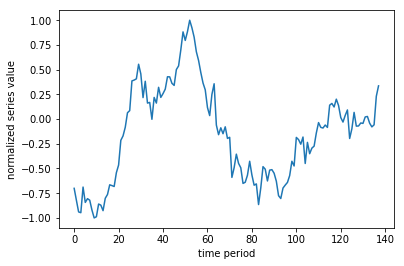

```python
# lets take a look at our time series
plt.plot(dataset)
plt.xlabel('time period')
plt.ylabel('normalized series value')
```

## 1.2 Cutting our time series into sequences

Time series is a sequence of numbers that can be represented mathematically as

$$s_{0},s_{1},s_{2},...,s_{P}$$

where $s_{p}$ is the numerical value of the time series at time period $p$ and where $P$ is the total length of the series. Treat this time series prediction as a regression problem, we need to use a sliding window to construct a set of associated input/output pairs to regress on as below:

[figure not shown]

For example - using a window of size T = 5 (as illustrated in the gif above) we produce a set of input/output pairs like the one shown in the table below

$$\begin{array}{c|c} \text{Input} & \text{Output}\\ \hline \color{CornflowerBlue} {\langle s_{1},s_{2},s_{3},s_{4},s_{5}\rangle} & \color{Goldenrod}{ s_{6}} \\ \ \color{CornflowerBlue} {\langle s_{2},s_{3},s_{4},s_{5},s_{6} \rangle } & \color{Goldenrod} {s_{7} } \\ \color{CornflowerBlue} {\vdots} & \color{Goldenrod} {\vdots}\\ \color{CornflowerBlue} { \langle s_{P-5},s_{P-4},s_{P-3},s_{P-2},s_{P-1} \rangle } & \color{Goldenrod} {s_{P}} \end{array}$$

Notice here that each input is a sequence (or vector) of length 5 (and in general has length equal to the window size T) while each corresponding output is a scalar value. Notice also how given a time series of length P and window size T = 5 as shown above, we created P - 5 input/output pairs. More generally, for a window size T we create P - T such pairs.

```python
# Write a function that transforms the input series and window-size
# into a set of input/output pairs for use with our RNN model
def window_transform_series(series, window_size):
    # containers for input/output pairs
    X = []
    y = []

    # loop through and append input/output to X/y
    for i in range(len(series)-window_size):
        X.append(series[i:i+window_size])
        y.append(series[i+window_size])

    # reshape each
    X = np.asarray(X)
    X.shape = (np.shape(X)[0:2])
    y = np.asarray(y)
    y.shape = (len(y),1)

    return X,y
```

```python
# Test
odd_nums = np.array([1,3,5,7,9,11,13])

# run a window of size 2 over the odd number sequence and display the results
window_size = 2
X,y = window_transform_series(odd_nums,window_size)

# print out input/output pairs --> here input = X, corresponding output = y
print ('--- the input X will look like ----')
print (X)

print ('--- the associated output y will look like ----')
print (y)

print ('the shape of X is ' + str(np.shape(X)))
print ('the shape of y is ' + str(np.shape(y)))
print('the type of X is ' + str(type(X)))
print('the type of y is ' + str(type(y)))
```

```
--- the input X will look like ----
[[ 1  3]
 [ 3  5]
 [ 5  7]
 [ 7  9]
 [ 9 11]]
--- the associated output y will look like ----
[[ 5]
 [ 7]
 [ 9]
 [11]
 [13]]
the shape of X is (5, 2)
the shape of y is (5, 1)
the type of X is <class 'numpy.ndarray'>
the type of y is <class 'numpy.ndarray'>
```

```python
# window the data
window_size = 7
X,y = window_transform_series(series = dataset,window_size = window_size)
```

## 1.3 Splitting into training and testing sets

In order to perform proper testing on our dataset we will lop off the last 1/3 of it for validation (or testing). That is once we train our model we have something to test it on (like any regression problem!).

Note how we are **not** splitting the dataset *randomly* as one typically would do when validating a regression model. This is because our input/output pairs *are related temporally*. We don't want to validate our model by training on a random subset of the series and then testing on another random subset, as this simulates the scenario that we receive new points *within the timeframe of our training set*.

We want to train on one solid chunk of the series (in our case, the first full 2/3 of it), and validate on a later chunk (the last 1/3) as this simulates how we would predict *future* values of a time series.

```python
# split our dataset into training / testing sets
train_test_split = int(np.ceil(2*len(y)/float(3)))   # set the split point

# partition the training set
X_train = X[:train_test_split,:]
y_train = y[:train_test_split]

# keep the last chunk for testing
X_test = X[train_test_split:,:]
y_test = y[train_test_split:]

# NOTE: to use keras's RNN LSTM module our input must be reshaped to [samples, window size, stepsize]
X_train = np.asarray(np.reshape(X_train, (X_train.shape[0], window_size, 1)))
X_test = np.asarray(np.reshape(X_test, (X_test.shape[0], window_size, 1)))
```

## 1.4 Build and run an RNN regression model

Use Keras to quickly build a two hidden layer RNN of the following specifications:

- layer 1 uses an LSTM module with 5 hidden units
- layer 2 uses a fully connected module with one unit
- the 'mean_squared_error' loss

```python
# import keras network libraries
from keras.models import Sequential
from keras.layers import Dense
from keras.layers import LSTM
import keras

# given - fix random seed - so we can all reproduce the same results on our default time series
np.random.seed(0)

# build an RNN to perform regression on our time series input/output data
model = Sequential()
model.add(LSTM(5, input_shape=(window_size, 1)))
model.add(Dense(1))

# use keras documentation recommended optimizer initialization
optimizer = keras.optimizers.RMSprop(lr=0.001, rho=0.9, epsilon=1e-08, decay=0.0)

# compile the model
model.compile(loss='mean_squared_error', optimizer=optimizer)
```

```python
# run it!
model.fit(X_train, y_train, epochs=1000, batch_size=50, verbose=0)
```

```
<keras.callbacks.History at 0x1158de588>
```

## 1.5 Checking model performance

```python
# generate predictions for training
train_predict = model.predict(X_train)
test_predict = model.predict(X_test)
```

```python
# print out training and testing errors
training_error = model.evaluate(X_train, y_train, verbose=0)
print('training error = ' + str(training_error))

testing_error = model.evaluate(X_test, y_test, verbose=0)
print('testing error = ' + str(testing_error))
```

```
training error = 0.0160044331781
testing error = 0.0139837302701
```

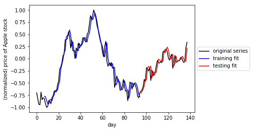

```python
# Plot the original series and predictions on training and testing sets
import matplotlib.pyplot as plt
%matplotlib inline

# plot original series
plt.plot(dataset,color = 'k')

# plot training set prediction
split_pt = train_test_split + window_size
plt.plot(np.arange(window_size,split_pt,1),train_predict,color = 'b')

# plot testing set prediction
plt.plot(np.arange(split_pt,split_pt + len(test_predict),1),test_predict,color = 'r')

# pretty up graph
plt.xlabel('day')
plt.ylabel('(normalized) price of Apple stock')
plt.legend(['original series','training fit','testing fit'],loc='center left', bbox_to_anchor=(1, 0.5))
plt.show()
```

# Problem 2: Create a sequence generator

Implementing a popular RNN architecture to create an English language sequence generator capable of producing semi-coherent English sentences from scratch by building them up character-by-character, using a complete version of Sir Arthur Conan Doyle's classic book The Adventures of Sherlock Holmes.

**Fun resources:**

- [Generate wacky sentences](http://www.cs.toronto.edu/~ilya/rnn.html) with this academic RNN text generator
- Various twitter bots that tweet automatically generated text like [this one](http://tweet-generator-alex.herokuapp.com/)
- the [NanoGenMo](https://github.com/NaNoGenMo/2016) annual contest to automatically produce a 50,000+ novel automatically
- [Robot Shakespeare](https://github.com/genekogan/RobotShakespeare) a text generator that automatically produces Shakespear-esk sentences

## 2.1 Preprocessing text dataset

```python
# read in the text, transforming everything to lower case
text = open('datasets/holmes.txt').read().lower()
print('our original text has ' + str(len(text)) + ' characters')
```

```
our original text has 581864 characters
```

Next, lets examine a bit of the raw text. Because we are interested in creating sentences of English words automatically by building up each word character-by-character, we only want to train on valid English words. In other words - we need to remove all of the other junk characters that aren't words!

```python
# print out the first 1000 characters of the raw text to get a sense of what we need to throw out
text[:1000]
```

```
"\ufeffproject gutenberg's the adventures of sherlock holmes, by arthur conan doyle\n\nthis ebook is for the use of anyone anywhere at no cost and with\nalmost no restrictions whatsoever.  you may copy it, give it away or\nre-use it under the terms of the project gutenberg license included\nwith thi…
```

Wow - there's a lot of junk here (i.e., weird uncommon character combinations - as this first character chunk contains the title and author page, as well as table of contents)! e.g., all the carriage return and newline sequences '\n' and '\r' sequences. We want to train our RNN on a large chunk of real english sentences - we don't want it to start thinking non-english words or strange characters are valid! - so lets clean up the data a bit.

First, since the dataset is so large and the first few hundred characters contain a lot of junk, lets cut it out. Lets also find-and-replace those newline tags with empty spaces.

```python
# find and replace '\n' and '\r' symbols - replacing them
text = text[1302:]
text = text.replace('\n',' ')
text = text.replace('\r',' ')
```

Lets see how the first 1000 characters of our text looks now!

```python
text[:1000]
```

```
"is eyes she eclipses and predominates the whole of her sex. it was not that he felt any emotion akin to love for irene adler. all emotions, and that one particularly, were abhorrent to his cold, precise but admirably balanced mind. he was, i take it, the most perfect reasoning and observing machine…
```

```python
# find all unique characters in the text
print(len(set(text)))
set(text)
```

[output not shown]

```python
# remove non-english characters
chars = ['$','%','&','(',')','*','-','/','0','1','2','3','4','5','6','7','8','9','@','à','â','è','é']
for c in chars:
    text = text.replace(c, ' ')

# shorten any extra dead space created above
text = text.replace('  ', ' ')
text[:500]
```

```
'is eyes she eclipses and predominates the whole of her sex. it was not that he felt any emotion akin to love for irene adler. all emotions, and that one particularly, were abhorrent to his cold, precise but admirably balanced mind. he was, i take it, the most perfect reasoning and observing machine…
```

```python
# count the number of unique characters in the text
chars = sorted(list(set(text)))

# print some of the text, as well as statistics
print ("this corpus has " +  str(len(text)) + " total number of characters")
print ("this corpus has " +  str(len(chars)) + " unique characters")
```

```
this corpus has 577113 total number of characters
this corpus has 35 unique characters
```

## 2.2 Cutting data into input/output pairs

We slide a window of length $T$ along our giant text corpus - everything in the window becomes one input while the character following becomes its corresponding output, as shown below using a window size of T = 5:

[figure not shown]

Notice one aspect of the sliding window in this gif that does not mirror the analaogous gif for time series in part 1 of the notebook - we do not need to slide the window along one character at a time but can move by a fixed step size $M$ greater than 1. This is done with large input texts (like ours which has over 500,000 characters) when sliding the window along one character at a time would create far too many input/output pairs to be able to reasonably compute with.

```python
# transforms the input text and window-size into a set of input/output pairs
def window_transform_text(text, window_size, step_size):
    # containers for input/output pairs
    inputs = []
    outputs = []
    j = 0
    # loop through and append input/output
    size = np.floor((len(text)-window_size)/step_size)
    for i in range(int(size)):
        inputs.append(text[j:j+window_size])
        outputs.append(text[j+window_size])
        j += step_size
    return inputs, outputs
```

```python
# window-ing the text
window_size = 50
step_size = 5
inputs, outputs = window_transform_text(text, window_size, step_size)
```

Lets print out a few input/output pairs to verify that we have made the right sort of stuff!

```python
print('input = ' + inputs[2])
print('output = ' + outputs[2])
print('--------------')
print('input = ' + inputs[100])
print('output = ' + outputs[100])
```

```
input = e eclipses and predominates the whole of her sex.
output = i
--------------
input = er excellent for drawing the veil from men's motiv
output = e
```

```python
# print out the number of unique characters in the dataset
chars = sorted(list(set(text)))
print ("this corpus has " +  str(len(chars)) + " unique characters")
print ('and these characters are ')
print (chars)
```

```
this corpus has 35 unique characters
and these characters are
[' ', '!', '"', "'", ',', '.', ':', ';', '?', 'a', 'b', 'c', 'd', 'e', 'f', 'g', 'h', 'i', 'j', 'k', 'l', 'm', 'n', 'o', 'p', 'q', 'r', 's', 't', 'u', 'v', 'w', 'x', 'y', 'z']
```

## 2.3 One-hot encoding characters

Transform each character in inputs/outputs into a vector with length equal to the number of unique characters in the text. This vector is all zeros except one location where we place a 1 - and this location is unique to each character type.

The first practical step towards doing this one-hot encoding is to form a dictionary mapping each unique character to a unique integer, and one dictionary to do the reverse mapping. We can then use these dictionaries to quickly make our one-hot encodings, as well as re-translate (from integers to characters) the results of our trained RNN classification model.

```python
# this dictionary is a function mapping each unique character to a unique integer
chars_to_indices = dict((c, i) for i, c in enumerate(chars))

# this dictionary is a function mapping each unique integer back to a unique character
indices_to_chars = dict((i, c) for i, c in enumerate(chars))
```

Next step is to transform input/output pairs - consisting of characters - to equivalent input/output pairs made up of one-hot encoded vectors.

```python
# transform character-based input/output into equivalent numerical versions
def encode_io_pairs(text, window_size, step_size):
    # number of unique chars
    chars = sorted(list(set(text)))
    num_chars = len(chars)

    # cut up text into character input/output pairs
    inputs, outputs = window_transform_text(text, window_size, step_size)

    # create empty vessels for one-hot encoded input/output
    X = np.zeros((len(inputs), window_size, num_chars), dtype=np.bool)
    y = np.zeros((len(inputs), num_chars), dtype=np.bool)

    # loop over inputs/outputs and tranform and store in X/y
    for i, sentence in enumerate(inputs):
        for t, char in enumerate(sentence):
            X[i, t, chars_to_indices[char]] = 1
        y[i, chars_to_indices[outputs[i]]] = 1

    return X,y
```

```python
# run the one-hot encoding function
window_size = 100
step_size = 5
X,y = encode_io_pairs(text, window_size, step_size)
```

## 2.4 Setting up RNN

Build a 3 layer RNN model of the following specification:

- layer 1 should be an LSTM module with 200 hidden units
- layer 2 should be a linear module, fully connected, with len(chars) hidden units
- layer 3 should be a softmax activation (since we are solving a *multiclass classification*)
- Use the **categorical_crossentropy** loss

```python
# import keras library
from keras.models import Sequential
from keras.layers import Dense, Activation, LSTM
from keras.optimizers import RMSprop
from keras.utils.data_utils import get_file
import keras
import random

# build the required RNN model
model = Sequential()
model.add(LSTM(200, input_shape=(window_size, len(chars))))
model.add(Dense(len(chars)))
model.add(Activation('softmax'))

# initialize optimizer
optimizer = keras.optimizers.RMSprop(lr=0.001, rho=0.9, epsilon=1e-08, decay=0.0)

# compile model
model.compile(loss='categorical_crossentropy', optimizer=optimizer)
```

## 2.5 Training RNN model for text generation

Lets first try it out on a small subset of the larger version.

```python
# a small subset of our input/output pairs
Xsmall = X[:10000,:,:]
ysmall = y[:10000,:]

# train the model
model.fit(Xsmall, ysmall, batch_size=512, epochs=30, verbose = 0)

# save weights
model.save_weights('model_weights/best_RNN_small_textdata_weights.hdf5')
```

- How do we make a given number of predictions (characters) based on this fitted model?

First we predict the next character after following any chunk of characters in the text of length equal to our chosen window size. Then we remove the first character in our input sequence and tack our prediction onto the end. This gives us a slightly changed sequence of inputs that still has length equal to the size of our window. We then feed in this updated input sequence into the model to predict the another character. Together then we have two predicted characters following our original input sequence. Repeating this process N times gives us N predicted characters.

```python
# function that uses trained model to predict a desired number of future characters
def predict_next_chars(model, input_chars, num_to_predict):
    # create output
    predicted_chars = ''
    for i in range(num_to_predict):
        # convert this round's predicted characters to numerical input
        x_test = np.zeros((1, window_size, len(chars)))
        for t, char in enumerate(input_chars):
            x_test[0, t, chars_to_indices[char]] = 1.

        # make this round's prediction
        test_predict = model.predict(x_test, verbose = 0)[0]

        # translate numerical prediction back to characters
        r = np.argmax(test_predict) # predict class of each test input
        d = indices_to_chars[r]

        # update predicted_chars and input
        predicted_chars += d
        input_chars += d
        input_chars = input_chars[1:]
    return predicted_chars
```

```python
# use `predict_next_chars` to predict 100 characters following it
start_inds = [100, 1000, 10000]

# load in weights
model.load_weights('model_weights/best_RNN_small_textdata_weights.hdf5')
for s in start_inds:
    start_index = s
    input_chars = text[start_index: start_index + window_size]

    # use the prediction function
    predict_input = predict_next_chars(model, input_chars, num_to_predict = 100)

    # print out input characters
    print('------------------')
    input_line = 'input chars = ' + '\n' +  input_chars + '"' + '\n'
    print(input_line)

    # print out predicted characters
    line = 'predicted chars = ' + '\n' +  predict_input + '"' + '\n'
    print(line)
```

```
------------------
input chars =
 to love for irene adler. all emotions, and that one particularly, were abhorrent to his cold, preci"

predicted chars =
s. in the ench hrss,and, ancrise an ulleand poupsince and befof he would has seegle has a salloud co"

------------------
input chars =
er, of dubious and questionable memory. i had seen little of holmes lately. my marriage had drifted "

predicted chars =
uut tha fobgit of eres, and toull drore ppopbobe cocclle for. if i sall clland nour popen in the rin"

------------------
input chars =
best attention." a slow and heavy step, which had been heard upon the stairs and in the passage, pau"

predicted chars =
st s mm me the ste the pindeded bo wo wall collllpvest wattran, i memprested somment and fofne, ine "
```

This looks ok, but not great. Now lets try the same experiment with a larger chunk of the data - with the first 100,000 input/output pairs.

```python
# a larger subset of input/output pairs
Xlarge = X[:100000,:,:]
ylarge = y[:100000,:]

# train the model
model.fit(Xlarge, ylarge, batch_size=512, epochs=30, verbose = 0)

# save weights
model.save_weights('model_weights/best_RNN_large_textdata_weights.hdf5')
```

```python
# use `predict_next_chars` to predict 100 characters following it
start_inds = [100, 1000, 10000, 100000]

# save output
f = open('text_gen_output/RNN_large_textdata_output.txt', 'w')  # create an output file to write too

# load weights
model.load_weights('model_weights/best_RNN_large_textdata_weights.hdf5')
for s in start_inds:
    start_index = s
    input_chars = text[start_index: start_index + window_size]

    # use the prediction function
    predict_input = predict_next_chars(model,input_chars,num_to_predict = 100)

    # print out input characters
    line = '-------------------' + '\n'
    print(line)
    f.write(line)

    input_line = 'input chars = ' + '\n' +  input_chars + '"' + '\n'
    print(input_line)
    f.write(input_line)

    # print out predicted characters
    predict_line = 'predicted chars = ' + '\n' +  predict_input + '"' + '\n'
    print(predict_line)
    f.write(predict_line)
f.close()
```

```
-------------------

input chars =
 to love for irene adler. all emotions, and that one particularly, were abhorrent to his cold, preci"

predicted chars =
st pappentaing the street of the brightss were all which i wrulm not be arry the roomss of a good of"

-------------------

input chars =
er, of dubious and questionable memory. i had seen little of holmes lately. my marriage had drifted "

predicted chars =
for him, but a conclind in the chands of the metter all the pair a passillant as he can and intled h"

-------------------

input chars =
best attention." a slow and heavy step, which had been heard upon the stairs and in the passage, pau"

predicted chars =
shall examsed the states and was to againtt the street of the belleap the come upon mystent of cours"

-------------------

input chars =
eaves the bank, she hurried across the road, and we heard the sharp clang of the bell. "i have seen "

predicted chars =
a lottle of his trant from the doom.  and holmes, as will be chave to you that i should be ash a lit"
```